# Immune cell infiltrates signature

Chao-Jen Wong

2023-03-16

Based on the longitudinal study, we have discovered that T cell proliferation, migration, and B cell-mediated immunity response are more prevalent in severely affected muscles, such as “IG-high” and “High.” The objective of this chapter is as follows:

1. Identify the enriched GO terms (biological processes) directly linked to T/B cells and circulating immunoglobulins in the longitudinal study (High or IG0high vs. control).
2. Determine the differentially expressed genes (High vs. control) associated with the enriched GO terms (from step 1), and use heatmap visualization to observe the trend of an increase in gene expression across all longitudinal and bilateral samples, associated with the severity of FSHD (characterised by STIR status, fat fraction/infiltration percent) and/or complement scoring.
3. Identify immune cell markers that are differentially expressed (High vs. control) using the IRIS database (Abbs 2009) as a source.

```r
library(tidyverse)
library(DESeq2)
library(pheatmap)
library(kableExtra)
suppressPackageStartupMessages(library(writexl))
suppressPackageStartupMessages(library(knitr))
suppressPackageStartupMessages(library(kableExtra))
suppressPackageStartupMessages(library(purrr))
library(wesanderson)
library(latex2exp)

pkg_dir <- "/Users/cwon2/CompBio/Wellstone_BiLateral_Biopsy"
fig_dir <- file.path(pkg_dir, "figures", "immune-infiltration")
load(file.path(pkg_dir, "data", "bilat_dds.rda"))
load(file.path(pkg_dir, "data", "longitudinal_dds.rda"))
load(file.path(pkg_dir, "data", "bilat_MLpredict.rda"))
load(file.path(pkg_dir, "data", "comprehensive_df.rda"))
source(file.path(pkg_dir, "scripts", "viz_tools.R"))

# tidy annotation from two datasets
anno_gencode35 <- as.data.frame(rowData(bilat_dds)) %>%
  rownames_to_column(var="gencode35_id") %>% # BiLat study using Gencode 36
  dplyr::mutate(ens_id=str_replace(gencode35_id, "\\..*", "")) %>%
  dplyr::distinct(gene_name, .keep_all = TRUE)

anno_ens88 <- as.data.frame(rowData(longitudinal_dds)) %>%
  rownames_to_column(var="ens88_id") %>% # longitudinal study ens v88
  dplyr::mutate(ens_id=str_replace(gene_id, "\\..*", "")) %>%
  dplyr::distinct(gene_name, .keep_all = TRUE) %>%
  dplyr::select(ens88_id, ens_id, gene_name)
# insert class to bilat_dds
col_data <- colData(bilat_dds) %>% as.data.frame() %>%
  left_join(bilat_MLpredict, by="sample_id")
bilat_dds$class <- col_data$class

longitudinal_dds$STIR_status <- if_else(longitudinal_dds$STIR_rating > 0, "STIR+", "STIR-")
```

## Enriched biological processes directly associated with T/B cells

The code chunk below (1) obtains the enriched GO terms in more affected muscles from the longitudinal study, supplementary table 5, and (2) retains the enriched GO terms containing the terms including `T cell`, `B cell`, `humoral`, `immunoglobulin`, and `complement`. Total 20 terms are extracted.

```r
high_enriched <- readxl::read_xlsx(file.path(pkg_dir, "extdata",
    "suppl_table_5_Candidate_Biomarkers_and_Enriched_Go.xlsx"),
    sheet=2, skip=2)

ig_enriched <- readxl::read_xlsx(file.path(pkg_dir, "extdata",
    "suppl_table_5_Candidate_Biomarkers_and_Enriched_Go.xlsx"),
    sheet=4, skip=2)

moderate_enriched <- readxl::read_xlsx(file.path(pkg_dir, "extdata",
    "suppl_table_5_Candidate_Biomarkers_and_Enriched_Go.xlsx"),
    sheet=6, skip=2)

# get the lymphocyte related GO ID
infiltrates_go <- high_enriched %>%
  dplyr::filter(str_detect(term, "T cell|B cell|humoral|immunoglobulin|complement"))

infiltrates_go %>%
  dplyr::select(category, over_represented_pvalue, term) %>%
  dplyr::rename(pvalue = over_represented_pvalue) %>%
  dplyr::mutate(pvalue = format(pvalue, scientific = TRUE)) %>%
  dplyr::arrange(category) %>%
  kbl(caption="Enriched biological process GO terms (n=20)  related to T/B cells, humoral immune response, and immunoglobulin domains.") %>%
  kable_paper("hover", full_width = F)
```

Enriched biological process GO terms (n=20) related to T/B cells, humoral immune response, and immunoglobulin domains.

| category | pvalue | term |
| --- | --- | --- |
| GO:0002455 | 4.391414e-10 | humoral immune response mediated by circulating immunoglobulin |
| GO:0002460 | 6.665762e-09 | adaptive immune response based on somatic recombination of immune receptors built from immunoglobulin superfamily domains |
| GO:0002920 | 2.865839e-11 | regulation of humoral immune response |
| GO:0006956 | 4.086619e-10 | complement activation |
| GO:0006957 | 1.965806e-04 | complement activation, alternative pathway |
| GO:0006958 | 1.619492e-10 | complement activation, classical pathway |
| GO:0006959 | 1.158839e-15 | humoral immune response |
| GO:0010818 | 2.450256e-09 | T cell chemotaxis |
| GO:0016064 | 1.175922e-08 | immunoglobulin mediated immune response |
| GO:0019724 | 1.380039e-08 | B cell mediated immunity |
| GO:0030449 | 7.071256e-11 | regulation of complement activation |
| GO:0031295 | 1.531739e-04 | T cell costimulation |
| GO:0042098 | 5.735434e-06 | T cell proliferation |
| GO:0042102 | 4.877625e-05 | positive regulation of T cell proliferation |
| GO:0042110 | 6.083250e-07 | T cell activation |
| GO:0042129 | 1.273162e-05 | regulation of T cell proliferation |
| GO:0050863 | 3.541698e-08 | regulation of T cell activation |
| GO:0050870 | 1.090819e-06 | positive regulation of T cell activation |
| GO:0072678 | 1.727781e-11 | T cell migration |
| GO:2000404 | 1.335915e-05 | regulation of T cell migration |

```r
#lymphocyte_go <- high_enriched %>%
#   dplyr::filter(str_detect(term, "lymphocyte"))
```

Display the p-values yielded by GSEA:

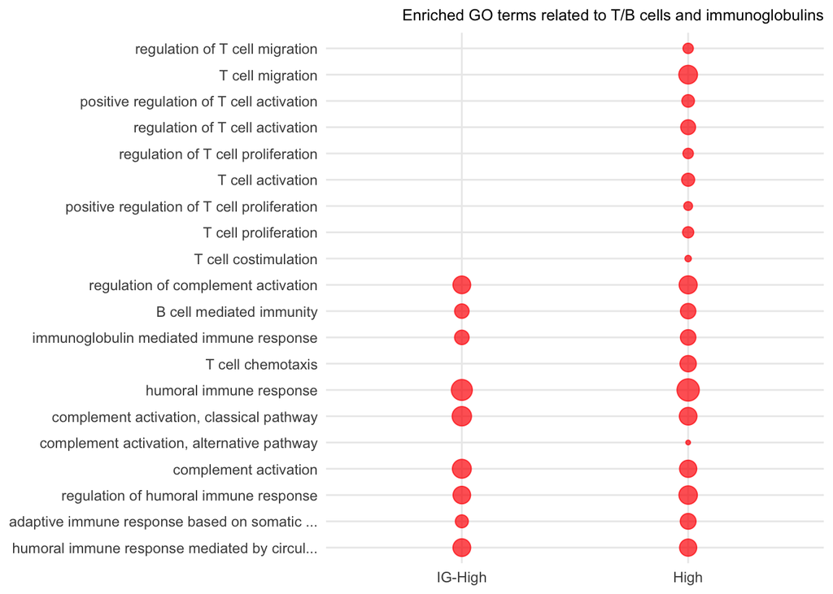

Enriched GO terms related to T and B cells and immunoglobulin domains. Red dots present the p-value of enriched GO terms in IG or High samples.

```r
df <- infiltrates_go %>%
  dplyr::select(category, term, over_represented_pvalue) %>%
  arrange(term) %>%
  left_join(dplyr::select(ig_enriched, category, over_represented_pvalue),
            by="category", suffix=c(".High", ".IG-High")) %>%
  tidyr::gather(key=class, value=pvalue, -category, -term) %>%
  dplyr::mutate(class = str_replace(class,
                                    "over_represented_pvalue.", ""),
                term = str_trunc(term, 45),
                class = factor(class, levels=c("IG-High", "High"))) %>%
  dplyr::mutate(log10pvalue = -log10(pvalue))

cat_levels <- df %>% dplyr::filter(class == "High") %>%
  dplyr::arrange(category) %>% pull(term)

df %>% dplyr::mutate(term=factor(term, levels=cat_levels)) %>%
  #dplyr::mutate(term = factor(term,levels=cat_levels)) %>%
  ggplot(aes(x=class, y=term)) +
    geom_point(aes(size=log10pvalue), color="red1", alpha=0.7,
               show.legend = FALSE) +
    theme_minimal() +
  labs(title="Enriched GO terms related to T/B cells and immunoglobulins") +
  theme(axis.title.x = element_blank(),
        plot.title = element_text(hjust=1, size=9.5),
        axis.title.y = element_blank())
```

```r
ggsave(file.path(fig_dir, "longitudinal-enriched-immunity-GO.pdf"),
       width=3.8, height=4.2)
```

## Significant genes associated with the T/B-associated enriched GO terms

The code chunk below aim to identify significantly expressed genes in High or IG-High (vs. contls) that are involved in the enriched GO terms obtained previously.

```r
high_sig <- readxl::read_xlsx(file.path(pkg_dir, "extdata",
    "suppl_table_5_Candidate_Biomarkers_and_Enriched_Go.xlsx"),
    sheet=1, skip=3) %>%
  dplyr::select(gene_name, gencode_id) %>%
  dplyr::mutate(ens_id = str_replace(gencode_id, "\\..*", ""))

ig_sig <- readxl::read_xlsx(file.path(pkg_dir, "extdata",
    "suppl_table_5_Candidate_Biomarkers_and_Enriched_Go.xlsx"),
    sheet=3, skip=3) %>%
  dplyr::select(gene_name, gencode_id) %>%
  dplyr::mutate(ens_id = str_replace(gencode_id, "\\..*", ""))
sig <- bind_rows(high_sig, ig_sig) %>%
  dplyr::distinct(gene_name, .keep_all=TRUE)

## keep the genes that involved in the infiltrates_go
gene2cat <- goseq::getgo(sig$ens_id, "hg38", "ensGene", fetch.cats = "GO:BP")
names(gene2cat) <- sig$ens_id
cat2gene <- goseq:::reversemapping(gene2cat)[infiltrates_go$category]
infiltrates_act <- map_dfr(cat2gene, function(cat_gene) {
  sig %>% dplyr::filter(ens_id %in% cat_gene)
}, .id="category") %>%
  arrange(category) %>%
  left_join(dplyr::select(infiltrates_go, category, term), by="category") %>%
  dplyr::rename(GOID = category) %>%
  distinct(gene_name, .keep_all=TRUE) %>%
  dplyr::rename(gene_id = gencode_id) %>%
  #arrange(gene_name) %>%
  dplyr::mutate(category = case_when(
    str_detect(term, "T cell") ~ "T cell migration / activation",
    str_detect(term, "humoral|complement") ~ "B cell mediated / humoral immune response",
    str_detect(term, "adaptive") ~ "adaptive immune response (IG domains)"
  )) %>%
  arrange(category, gene_name)
```

Total 95 B/T cell immunity response significant markers are identified.

### Heatmap: Longitudinal study

Now we visualized the trend of the increased expression levels on the longitidunal samples, arranges by ML-defined classes: Control, Mild, Moderate, IG-High, High, and Muscle-low.

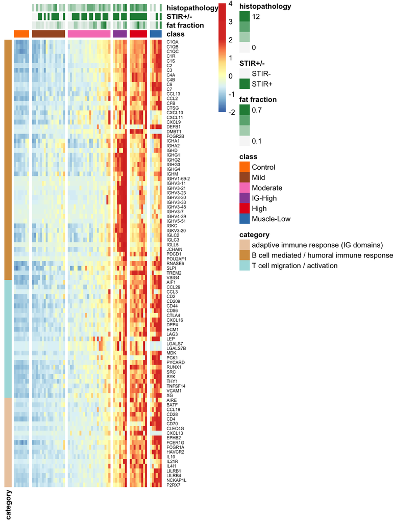

Heatmap demonstrating the increased expression trend on more affected muscle. Color presented the row-wised z-score of expression levels.

```r
cluster_color <- c(Control="#ff7f00",
                    Mild="#a65628",
                    Moderate="#f781bf",
                    `IG-High`="#984ea3", High="#e41a1c",
                   `Muscle-Low`="#377eb8")
category_color <- wes_palette("Darjeeling2", n=4)[c(1,3,4)]
names(category_color) <- levels(factor(infiltrates_act$category))
ann_cor <- list(class = cluster_color, category = category_color)

# include column annotaion: class, fat fraction, STIR rating, and histophatology
col <- c("#f7f7f7", "#238b45")
annotation_col <- colData(longitudinal_dds) %>% as.data.frame() %>%
  dplyr::select(cluster, fat_fraction, STIR_status,
                #STIR_rating,
                Pathology.Score) %>%
  dplyr::rename(class=cluster, `fat fraction`=fat_fraction,
                `STIR+/-` = STIR_status,
                `histopathology` = Pathology.Score) %>%
  dplyr::mutate(`STIR+/-` = factor(`STIR+/-`))

ann_cor <-  list(class = cluster_color, category = category_color,
                 `fat fraction` = col, `STIR+/-` = c(`STIR-`="#f7f7f7",
                                                     `STIR+`="#238b45"),
                 `histopathology` = col)
markers_heatmp_group_by_types_class(markers = infiltrates_act,
                                    dds = longitudinal_dds,
                                    factor = "cluster",
                                    annotation_col = annotation_col,
                                    ann_cor = ann_cor,
                                    annotation_legend=TRUE)
```

### Heatmap: bilateral study

Heatmap of the expression levels of 95 genes on the bilateral samples.

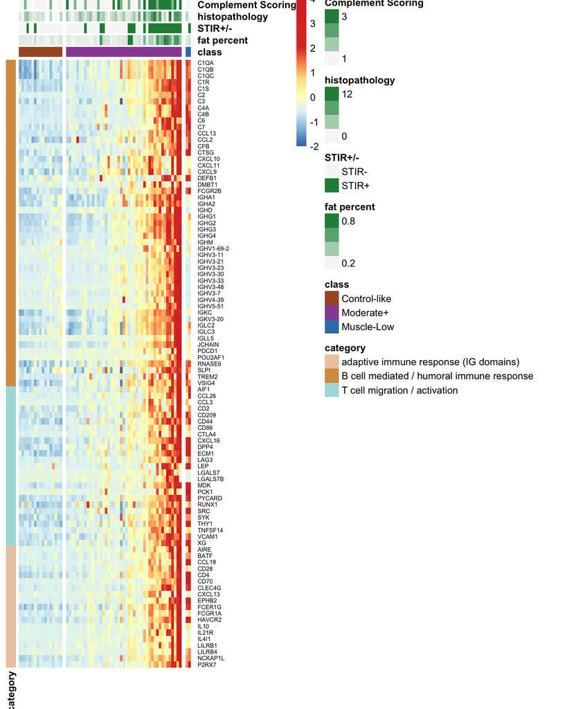

```r
annotation_col <- comprehensive_df %>%
  drop_na(class) %>%
  dplyr::select(sample_id, class, Fat_Infilt_Percent, STIR_status,
                `Cumulative Score`, `Complement Scoring`) %>%
  dplyr::rename(`fat percent` = Fat_Infilt_Percent,
                `STIR+/-` = STIR_status,
                `histopathology` = `Cumulative Score`) %>%
  column_to_rownames(var="sample_id")

class_color <- c(`Control-like`="#a65628",
                    `Moderate+`="#984ea3",
                    `Muscle-Low`="#377eb8")
ann_cor <- list(class = class_color, category = category_color,
                `fat percent` = col,
                `STIR+/-` = c(`STIR-`="#f7f7f7", `STIR+`="#238b45"),
                `histopathology` = col,
                `Complement Scoring` = col)

markers <- infiltrates_act %>%
  left_join(dplyr::select(anno_gencode35, ens_id, gencode35_id),
            by="ens_id") %>%
  dplyr::select(-gene_id) %>%
  dplyr::rename(gene_id = gencode35_id) %>%
  drop_na(gene_id)

markers_heatmp_group_by_types_class(markers = markers,
                                    dds = bilat_dds,
                                    factor = "class",
                                    annotation_legend=TRUE,
                                    annotation_col = annotation_col,
                                    ann_cor = ann_cor)
```

## Immune cell infiltrate signature

Using a generic cell-type marker dataset from the immune response in silico (IRIS) (Abbas 2009), we detected 63 immune cell markers whose expression levels are signficiantly elevated in more affected muscles. With additonal significant immunity-related markers, including such as cytokine receptors in B cells (IL-4R, IL-21R), STAT6, Leukocyte immunoglobulin-like receptor B family (LILRB4, LILRB5), T cell surface antigens (CD2 and CD4), T and B cell interaction and migration (CCL19), and STAT6, we demonstrated a immune cell infiltrate signatures in both longitudinal and bilateral samples.

Code chunk below identified 63 immune cell markers as a subset of the IRIS database (Abbas 2009).

```r
library(PLIER)
data(bloodCellMarkersIRISDMAP)
# about 860 markers
blood_iris <- as.data.frame(bloodCellMarkersIRISDMAP) %>%
  rownames_to_column(var="gene_name") %>%
  dplyr::select(gene_name, starts_with("IRIS")) %>%
  dplyr::filter(rowSums(across(where(is.numeric))) > 0)

# 63 are DE in High
sig_blood_iris <- high_sig %>%
  inner_join(blood_iris, by="gene_name")
category <- names(sig_blood_iris)[4:ncol(sig_blood_iris)]
sig_blood_iris$category <-
  apply(sig_blood_iris[, 4:ncol(sig_blood_iris)], 1,
        function(x) {
    tmp <- if_else(unlist(as.vector(x)) == 1, TRUE, FALSE)
    return(category[tmp][1])
       })

sig_blood_iris  <- sig_blood_iris %>%
  dplyr::select(gene_name, gencode_id, ens_id, category) %>%
  dplyr::rename(gene_id = gencode_id) %>%
  dplyr::mutate(category = str_replace(category, "IRIS_", "")) %>%
  dplyr::mutate(category = str_replace(category, "\\-.*", "")) %>%
  arrange(category, gene_name)

# add others: IL-4R, IL-21R, LILRB4, LILRB5, CD2, CD4, CCL19
others <- data.frame(gene_name = c("IL4R", "IL21R", "LILRB4",
                                   "LILRB5",
                                   "CD2", "CD4", "CCL19", "STAT6")) %>%
  left_join(anno_ens88, by="gene_name") %>%
  dplyr::rename(gene_id = ens88_id) %>%
  add_column(category="Others") %>%
  arrange(gene_name)

sig_blood_iris <- bind_rows(sig_blood_iris, others) %>%
  dplyr::mutate(category = factor(category,
                                  levels = c("Bcell", "CD4Tcell", "CD8Tcell",
                                             "DendriticCell",
                                             "Monocyte", "Neutrophil",
                                             "NKcell", "PlasmaCell",
                                             "Others")))
```

### Viz the immune cell infiltrate siganiture from the longitudinal study

The following heatmap illustrates that there is a tendency of higher expression levels in muscles that are more affected.

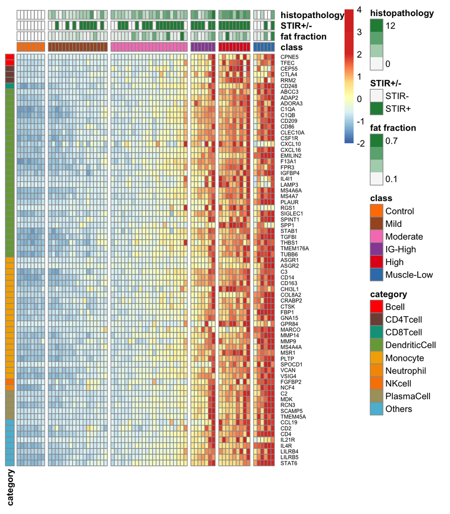

Heapmap demonstrating the expression levels (by row-wise z-score of log10(TPM++1) in the longitudinal study.

```r
cluster_color <- c(Control="#ff7f00",
                    Mild="#a65628",
                    Moderate="#f781bf",
                    `IG-High`="#984ea3", High="#e41a1c",
                   `Muscle-Low`="#377eb8")

col <- c("#f7f7f7", "#238b45")
annotation_col <- colData(longitudinal_dds) %>% as.data.frame() %>%
  dplyr::select(cluster, fat_fraction, STIR_status,
                #STIR_rating,
                Pathology.Score) %>%
  dplyr::rename(class=cluster, `fat fraction`=fat_fraction,
                `STIR+/-` = STIR_status,
                `histopathology` = Pathology.Score) %>%
  dplyr::mutate(`STIR+/-` = factor(`STIR+/-`))

category_color <- wes_palette("Darjeeling1", n=9, typ="continuous")[1:9]
names(category_color) <- levels(sig_blood_iris$category)

ann_cor <-  list(class = cluster_color, category = category_color,
                 `fat fraction` = col, `STIR+/-` = c(`STIR-`="#f7f7f7",
                                                     `STIR+`="#238b45"),
                 `histopathology` = col)
markers_heatmp_group_by_types_class(markers = sig_blood_iris,
                                    dds = longitudinal_dds,
                                    factor = "cluster",
                                    annotation_col = annotation_col,
                                    ann_cor = ann_cor)
```

### Bilateral study

The heatmap for the bilateral study below incorporates the complement scoring.

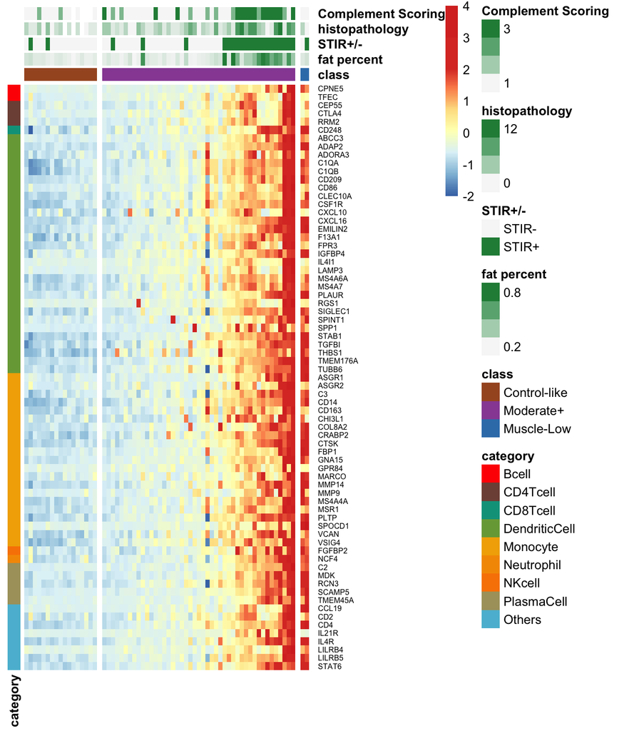

```r
annotation_col <- comprehensive_df %>%
  drop_na(class) %>%
  dplyr::select(sample_id, class, Fat_Infilt_Percent, STIR_status,
                `Cumulative Score`, `Complement Scoring`) %>%
  dplyr::rename(`fat percent` = Fat_Infilt_Percent,
                `STIR+/-` = STIR_status,
                `histopathology` = `Cumulative Score`) %>%
  column_to_rownames(var="sample_id")

class_color <- c(`Control-like`="#a65628",
                    `Moderate+`="#984ea3",
                    `Muscle-Low`="#377eb8")
ann_cor <- list(class = class_color, category = category_color,
                `fat percent` = col,
                `STIR+/-` = c(`STIR-`="#f7f7f7", `STIR+`="#238b45"),
                `histopathology` = col,
                `Complement Scoring` = col)

# update sig_blood_iris gene_id to gencode35_id
tmp <- sig_blood_iris %>%
  left_join(dplyr::select(anno_gencode35, ens_id, gencode35_id),
            by="ens_id") %>%
  dplyr::select(-gene_id) %>%
  dplyr::rename(gene_id = gencode35_id)

markers_heatmp_group_by_types_class(markers = tmp,
                                    dds = bilat_dds,
                                    factor = "class",
                                    annotation_col = annotation_col,
                                    ann_cor = ann_cor )
```

## Complement scoring vs. immune cell infiltrates signature

```r
tpm <- assays(bilat_dds[tmp$gene_id])[["TPM"]]

signature <- colMeans(log10(tpm+1)) %>% as.data.frame() %>%
  rownames_to_column(var="sample_id")
names(signature)[2] <- "avg_z_score"

tmp_df <- comprehensive_df %>%
  dplyr::select(sample_id, `Complement Scoring`, `STIR_status`,
                `STIR_RATING`) %>%
  left_join(signature, by="sample_id") %>%
  drop_na(`Complement Scoring`, `avg_z_score`)

tmp_df %>%
  drop_na(`Complement Scoring`, `avg_z_score`) %>%
  dplyr::select(`Complement Scoring`, `avg_z_score`) %>%
  corrr::correlate(., method="spearman")
```

```
## # A tibble: 2 × 3
##   term               `Complement Scoring` avg_z_score
##   <chr>                             <dbl>       <dbl>
## 1 Complement Scoring               NA           0.456
## 2 avg_z_score                       0.456      NA
```

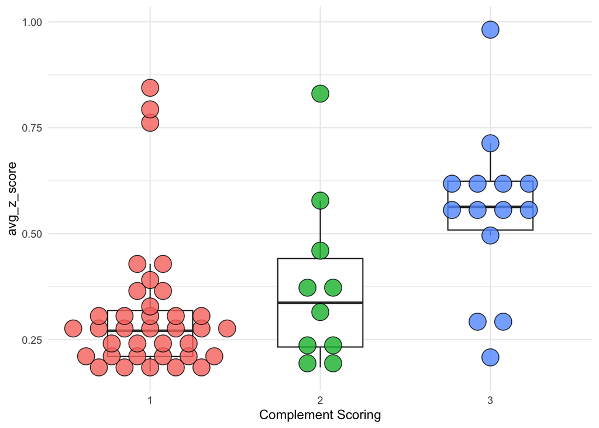

Dotplot of immune cell infiltrates signature (presented by average z-score) groups by complement scoring 1, 2, and 3.

```r
tmp_df %>%
  drop_na(`Complement Scoring`, `avg_z_score`) %>%
  dplyr::mutate(`Complement Scoring`= factor(`Complement Scoring`)) %>%
  ggplot(aes(x=`Complement Scoring`, y=avg_z_score)) +
    geom_boxplot(width=0.5, outlier.shape = NA) +
    geom_dotplot(aes(fill=`Complement Scoring`),
                 binaxis='y', stackdir='center',
                 show.legend = FALSE, alpha=0.8,
                 stackratio=1.5, dotsize=1.5) +
    theme_minimal()
```

## STIR status vs. immune cell infiltrates signature

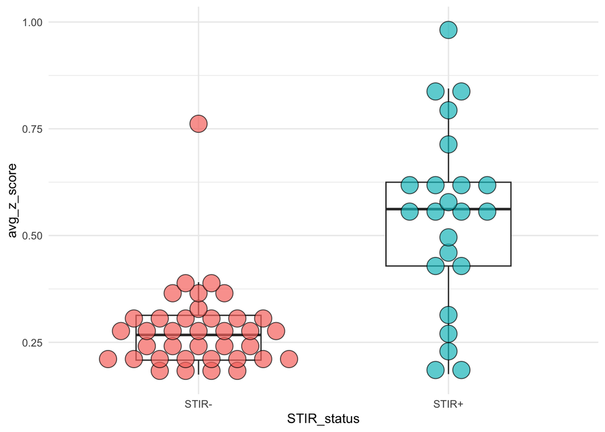

```r
tmp_df %>%
  drop_na(`STIR_status`, `avg_z_score`) %>%
  ggplot(aes(x=`STIR_status`, y=avg_z_score)) +
    geom_boxplot(width=0.5, outlier.shape = NA) +
    geom_dotplot(aes(fill=`STIR_status`),
                 binaxis='y', stackdir='center',
                 show.legend = FALSE,
                 stackratio=1.5, dotsize=1.5, alpha=0.7) +
    theme_minimal()
```

```r
x <- tmp_df %>%
  drop_na(`STIR_status`, `avg_z_score`) %>%
  dplyr::select(sample_id, `STIR_status`, `avg_z_score`) %>%
  spread(key=STIR_status, value=avg_z_score)
wilcox.test(x$`STIR-`, x$`STIR+` )
```

```
##
##  Wilcoxon rank sum exact test
##
## data:  x$`STIR-` and x$`STIR+`
## W = 135, p-value = 3.177e-06
## alternative hypothesis: true location shift is not equal to 0
```

## Bilateral comparison analysis for the immune cell infiltrate markers

1. write a supplementary table listing `sig_blood_iris` and `infiltrates_act`
2. bilateral comparison analysis for `sig_blood_iris` and `infiltrates_act`: check the gitbook chap 7: how did I do it?
- input: data frame with columns gene_id, gene_names, Left and right
- output: correlation coefficient table

In the previous section, we identified a signature of immune cell infiltrates characterized by 63 immune cell markers in the longitudinal study. Here we compute their expression correlation between left and right muscles in the bilateral study.

The code below shows the tools to compute the correlation between L and R muscles on the immune cell infiltrate markers.

```r
col_data <- colData(bilat_dds) %>% as.data.frame()
# convert gene_id to Gencode35
markers <- sig_blood_iris %>%
  left_join(dplyr::select(anno_gencode35, ens_id, gencode35_id),
            by="ens_id") %>%
  dplyr::select(-gene_id) %>%
  dplyr::rename(gene_id = gencode35_id)

.markers_bilateral_correlation <- function(markers, dds) {
  tpm <- assays(dds[markers$gene_id])[["TPM"]] %>% t(.) %>%
      as.data.frame() %>%
      rownames_to_column(var="sample_id") %>%
      gather(key=gene_id, value=TPM, -sample_id) %>%
      left_join(dplyr::select(col_data, sample_id, location,
                              Subject), by="sample_id") %>%
      dplyr::select(-sample_id) %>%
      spread(key=location, value=TPM) %>%
      drop_na(L, R)
  gene_cor <- tpm %>%
    dplyr::mutate(L_log = log10(L+1), R_log=log10(R+1)) %>%
    group_by(gene_id) %>%
    summarise(Pearson_by_TPM=cor(L, R),
              Pearson_by_log10TPM = cor(L_log, R_log)) %>%
    dplyr::left_join(markers, by="gene_id") %>%
    arrange(desc(Pearson_by_log10TPM)) %>%
    dplyr::relocate(gene_name, .after=gene_id)

  return(gene_cor)
}

.avg_TPM_by_class <- function(markers, dds) {
   avg_TPM <- map_dfc(levels(dds$class), function(x) {
     assays(dds[markers$gene_id])[["TPM"]][, dds$class == x] %>%
       rowMeans(.)
   }) %>%
     tibble::add_column(gene_id = markers$gene_id) %>%
     dplyr::rename_with(~paste0(levels(dds$class), " avg TPM"),
                        starts_with("..."))
}
```

Display the correlation and average TPM grouped by ML-based classes.

```r
gene_cor_63 <- .markers_bilateral_correlation(markers=markers,
                                           dds=bilat_dds) %>%
  dplyr::left_join(.avg_TPM_by_class(markers = markers, dds=bilat_dds),
                   by="gene_id")

gene_cor_63 %>%
  dplyr::select(-Pearson_by_TPM) %>%
  kbl(caption="Sixty-three significant immune cell markers correlation analysis between left and right biopsied muscles. The Peason correlation coefficients are compuated using the expression levels presented by Log10(TPM+1).") %>%
  kable_styling()
```

| gene_id | gene_name | Pearson_by_log10TPM | ens_id | category | Control-like avg TPM | Moderate+ avg TPM | Muscle-Low avg TPM |
| --- | --- | --- | --- | --- | --- | --- | --- |
| ENSG00000038945.15 | MSR1 | 0.8538713 | ENSG00000038945 | Monocyte | 0.1165807 | 0.5913336 | 0.8065051 |
| ENSG00000124772.12 | CPNE5 | 0.8373333 | ENSG00000124772 | Bcell | 0.0443273 | 0.3835624 | 1.0004216 |
| ENSG00000114013.16 | CD86 | 0.8269231 | ENSG00000114013 | DendriticCell | 0.0663682 | 0.3421849 | 0.4462872 |
| ENSG00000132514.13 | CLEC10A | 0.8181479 | ENSG00000132514 | DendriticCell | 0.3866177 | 1.7920233 | 3.3907985 |
| ENSG00000105967.16 | TFEC | 0.8176975 | ENSG00000105967 | Bcell | 0.0234566 | 0.1235314 | 0.1023323 |
| ENSG00000173369.17 | C1QB | 0.8099608 | ENSG00000173369 | DendriticCell | 2.0357169 | 13.7189810 | 28.4657562 |
| ENSG00000177575.12 | CD163 | 0.8078951 | ENSG00000177575 | Monocyte | 0.3361453 | 1.8946880 | 2.0304719 |
| ENSG00000110077.14 | MS4A6A | 0.8063214 | ENSG00000110077 | DendriticCell | 0.4436241 | 2.1606915 | 3.6416739 |
| ENSG00000138180.16 | CEP55 | 0.7993619 | ENSG00000138180 | CD4Tcell | 0.0348918 | 0.1666287 | 0.2252888 |
| ENSG00000163599.17 | CTLA4 | 0.7880751 | ENSG00000163599 | CD4Tcell | 0.0315704 | 0.2644233 | 0.1854032 |
| ENSG00000166927.13 | MS4A7 | 0.7842506 | ENSG00000166927 | DendriticCell | 0.2090296 | 1.1084212 | 1.9491638 |
| ENSG00000170458.14 | CD14 | 0.7842175 | ENSG00000170458 | Monocyte | 1.7751882 | 7.7468300 | 21.4222643 |
| ENSG00000124491.16 | F13A1 | 0.7788406 | ENSG00000124491 | DendriticCell | 2.0078292 | 12.2302448 | 21.8912499 |
| ENSG00000182578.14 | CSF1R | 0.7750512 | ENSG00000182578 | DendriticCell | 0.7874655 | 3.3187330 | 7.1733571 |
| ENSG00000137441.8 | FGFBP2 | 0.7745707 | ENSG00000137441 | NKcell | 0.4225620 | 3.5214963 | 12.7187471 |
| ENSG00000161944.16 | ASGR2 | 0.7740608 | ENSG00000161944 | Monocyte | 0.0212327 | 0.1023889 | 0.1496403 |
| ENSG00000282608.2 | ADORA3 | 0.7736084 | ENSG00000282608 | DendriticCell | 0.0386997 | 0.1584448 | 0.2628639 |
| ENSG00000186818.12 | LILRB4 | 0.7629389 | ENSG00000186818 | Others | 0.0032613 | 0.0281318 | 0.0722317 |
| ENSG00000173372.17 | C1QA | 0.7445602 | ENSG00000173372 | DendriticCell | 3.4317578 | 19.1178534 | 52.6300218 |
| ENSG00000116824.5 | CD2 | 0.7414507 | ENSG00000116824 | Others | 0.5136958 | 2.7983896 | 3.0646508 |
| ENSG00000161921.16 | CXCL16 | 0.7398670 | ENSG00000161921 | DendriticCell | 0.3268772 | 1.4080810 | 5.0737114 |
| ENSG00000010327.10 | STAB1 | 0.7266172 | ENSG00000010327 | DendriticCell | 1.5300961 | 5.3923377 | 17.3660509 |
| ENSG00000103522.16 | IL21R | 0.7225309 | ENSG00000103522 | Others | 0.0288943 | 0.4792686 | 0.1039427 |
| ENSG00000110079.18 | MS4A4A | 0.7206380 | ENSG00000110079 | Monocyte | 0.1930113 | 1.0180924 | 2.7351409 |
| ENSG00000078081.8 | LAMP3 | 0.7185273 | ENSG00000078081 | DendriticCell | 0.0108336 | 0.1663221 | 0.2174447 |
| ENSG00000090104.12 | RGS1 | 0.7173044 | ENSG00000090104 | DendriticCell | 0.0130089 | 0.2018628 | 0.1915478 |
| ENSG00000143320.9 | CRABP2 | 0.7144369 | ENSG00000143320 | Monocyte | 0.6114227 | 3.8166488 | 13.9456375 |
| ENSG00000019169.10 | MARCO | 0.7105930 | ENSG00000019169 | Monocyte | 0.1199304 | 0.6352074 | 1.9900735 |
| ENSG00000184060.11 | ADAP2 | 0.7103740 | ENSG00000184060 | DendriticCell | 0.3838474 | 1.1441190 | 3.2110364 |
| ENSG00000166278.15 | C2 | 0.7007918 | ENSG00000166278 | PlasmaCell | 0.0039973 | 0.0403557 | 0.1117194 |
| ENSG00000110492.15 | MDK | 0.7003678 | ENSG00000110492 | PlasmaCell | 0.5089112 | 2.5043028 | 13.2510295 |
| ENSG00000181458.10 | TMEM45A | 0.7003172 | ENSG00000181458 | PlasmaCell | 0.0529060 | 0.3722313 | 1.0593557 |
| ENSG00000104951.16 | IL4I1 | 0.6975342 | ENSG00000104951 | DendriticCell | 0.0220052 | 0.3013386 | 0.1689496 |
| ENSG00000077238.14 | IL4R | 0.6970081 | ENSG00000077238 | Others | 0.9802568 | 3.5371779 | 15.3524367 |
| ENSG00000157227.13 | MMP14 | 0.6813758 | ENSG00000157227 | Monocyte | 2.4939224 | 10.9206905 | 68.0308145 |
| ENSG00000143387.13 | CTSK | 0.6812790 | ENSG00000143387 | Monocyte | 2.5631582 | 12.3782990 | 70.4075115 |
| ENSG00000038427.16 | VCAN | 0.6795530 | ENSG00000038427 | Monocyte | 0.5364233 | 2.1562978 | 3.3628331 |
| ENSG00000172724.12 | CCL19 | 0.6771104 | ENSG00000172724 | Others | 0.0506337 | 2.0168338 | 34.8952268 |
| ENSG00000120708.17 | TGFBI | 0.6748693 | ENSG00000120708 | DendriticCell | 2.4659110 | 8.9473151 | 33.0267668 |
| ENSG00000002933.9 | TMEM176A | 0.6728172 | ENSG00000002933 | DendriticCell | 0.3762751 | 1.8857893 | 11.2110257 |
| ENSG00000171848.15 | RRM2 | 0.6609791 | ENSG00000171848 | CD4Tcell | 0.0090876 | 0.0662736 | 0.1102069 |
| ENSG00000169245.6 | CXCL10 | 0.6550995 | ENSG00000169245 | DendriticCell | 0.5894382 | 5.9803700 | 2.1547531 |
| ENSG00000166888.12 | STAT6 | 0.6500805 | ENSG00000166888 | Others | 1.7841065 | 5.8704648 | 30.1303223 |
| ENSG00000133048.13 | CHI3L1 | 0.6346830 | ENSG00000133048 | Monocyte | 0.1946220 | 2.1621032 | 2.7397122 |
| ENSG00000010610.10 | CD4 | 0.6261569 | ENSG00000010610 | Others | 0.5141389 | 2.7303825 | 27.4443352 |
| ENSG00000174807.4 | CD248 | 0.6261514 | ENSG00000174807 | CD8Tcell | 14.3514643 | 48.2904687 | 253.0578657 |
| ENSG00000198794.12 | SCAMP5 | 0.6259889 | ENSG00000198794 | PlasmaCell | 0.0735910 | 0.4475840 | 2.3682200 |
| ENSG00000165140.11 | FBP1 | 0.6256957 | ENSG00000165140 | Monocyte | 0.1543315 | 0.6023780 | 3.7040663 |
| ENSG00000137801.11 | THBS1 | 0.5769849 | ENSG00000137801 | DendriticCell | 0.8099008 | 5.0986959 | 17.6310690 |
| ENSG00000100365.16 | NCF4 | 0.5626164 | ENSG00000100365 | Neutrophil | 0.3574015 | 1.3059616 | 3.1460980 |
| ENSG00000141505.12 | ASGR1 | 0.5509758 | ENSG00000141505 | Monocyte | 0.0351094 | 0.1354246 | 0.6025999 |
| ENSG00000142552.8 | RCN3 | 0.5367903 | ENSG00000142552 | PlasmaCell | 3.1691866 | 10.1816596 | 48.4596901 |
| ENSG00000171812.13 | COL8A2 | 0.5351123 | ENSG00000171812 | Monocyte | 0.1500623 | 0.9979313 | 3.0772092 |
| ENSG00000132205.11 | EMILIN2 | 0.5297056 | ENSG00000132205 | DendriticCell | 0.3997817 | 1.9355804 | 10.0447402 |
| ENSG00000108846.16 | ABCC3 | 0.5169606 | ENSG00000108846 | DendriticCell | 0.0253774 | 0.2010368 | 0.4090524 |
| ENSG00000060558.4 | GNA15 | 0.5164559 | ENSG00000060558 | Monocyte | 0.1154703 | 0.6176169 | 1.4995404 |
| ENSG00000155659.15 | VSIG4 | 0.5133328 | ENSG00000155659 | Monocyte | 0.5261769 | 2.2279206 | 4.3380216 |
| ENSG00000088827.12 | SIGLEC1 | 0.5044042 | ENSG00000088827 | DendriticCell | 1.0464540 | 4.0403822 | 10.0460345 |
| ENSG00000100979.15 | PLTP | 0.5012153 | ENSG00000100979 | Monocyte | 1.8178334 | 9.1650567 | 44.0062775 |
| ENSG00000166145.14 | SPINT1 | 0.5003076 | ENSG00000166145 | DendriticCell | 0.0426139 | 0.1894087 | 0.7413172 |
| ENSG00000100985.7 | MMP9 | 0.4984437 | ENSG00000100985 | Monocyte | 0.1003691 | 1.5203490 | 8.2657241 |
| ENSG00000187474.5 | FPR3 | 0.4933989 | ENSG00000187474 | DendriticCell | 0.3026753 | 1.7773001 | 1.9219966 |
| ENSG00000139572.4 | GPR84 | 0.4751397 | ENSG00000139572 | Monocyte | 0.0077004 | 0.0773290 | 0.0618142 |
| ENSG00000105609.17 | LILRB5 | 0.4640090 | ENSG00000105609 | Others | 0.1857144 | 0.7666013 | 1.9553274 |
| ENSG00000090659.18 | CD209 | 0.4608114 | ENSG00000090659 | DendriticCell | 0.2322114 | 1.2533845 | 3.3028487 |
| ENSG00000176014.13 | TUBB6 | 0.4602100 | ENSG00000176014 | DendriticCell | 3.5972900 | 11.0828601 | 48.3484150 |
| ENSG00000118785.14 | SPP1 | 0.4479528 | ENSG00000118785 | DendriticCell | 0.0207772 | 1.1074521 | 1.8615908 |
| ENSG00000011422.12 | PLAUR | 0.4301508 | ENSG00000011422 | DendriticCell | 0.1783956 | 0.5793819 | 2.2774659 |
| ENSG00000125730.17 | C3 | 0.4263273 | ENSG00000125730 | Monocyte | 4.4394449 | 25.6278376 | 67.5924876 |
| ENSG00000141753.7 | IGFBP4 | 0.3779018 | ENSG00000141753 | DendriticCell | 47.2044767 | 167.3634231 | 1281.8420877 |
| ENSG00000134668.12 | SPOCD1 | 0.3293381 | ENSG00000134668 | Monocyte | 0.0101972 | 0.0482261 | 0.3785615 |